# Analyzing a Cereal Rating Standard

Chileshe Otieno

[Back to Homepage](https://caseyot6.github.io/)

Data Source: https://www.kaggle.com/crawford/80-cereals

The data is compiled information on nutritional content for various cereals as well as a rating standard applied to each brand of cereal.

From this data source, cold cereals were selected (cereals requiring no heating to be served).

- Columns/variables selected:
- Name (Factor), describes name of cereal brand
- Calories (Integer), describes calories in grams per serving of the cereal
- Protein (Integer), describes protein in grams per serving of the cereal
- Fat (Numeric), describes fat in grams per serving of the cereal
- Carbo (Numeric), describes complex carbohydrates in grams per serving of the cereal
- Sugars (Integer), describes sugar in grams per serving of the cereal
- Rating (Numeric), describes rating (0-100) assigned to each brand of cereal

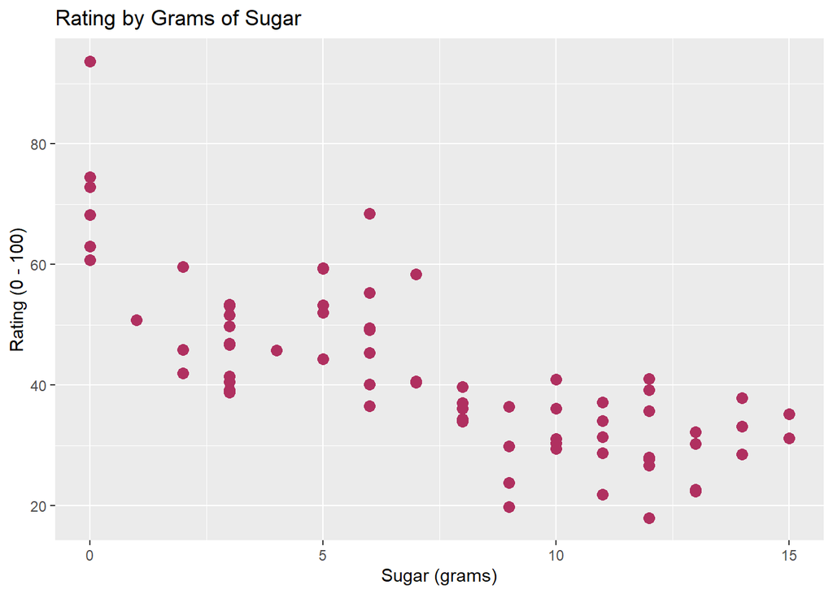

There is a negative relationship between the cereal ratings and grams of sugar present in the cereal.

Based on a linear regression, the relationship is statistically significant at the alpha = .01 level.

R-squared is .5667, indicating that the linear model’s relationship between the two accounts for about 56% of the variation in the data.

```r
  summary(lm(data = Cereal, rating~sugars))
```

```
##
## Call:
## lm(formula = rating ~ sugars, data = Cereal)
##
## Residuals:
##     Min      1Q  Median      3Q     Max
## -17.839  -5.573  -1.599   4.903  34.175
##
## Coefficients:
##             Estimate Std. Error t value Pr(>|t|)
## (Intercept)  59.5297     2.0952  28.413  < 2e-16 ***
## sugars       -2.4297     0.2504  -9.703 1.04e-14 ***
## ---
## Signif. codes:  0 '***' 0.001 '**' 0.01 '*' 0.05 '.' 0.1 ' ' 1
##
## Residual standard error: 9.27 on 72 degrees of freedom
## Multiple R-squared:  0.5667, Adjusted R-squared:  0.5606
## F-statistic: 94.15 on 1 and 72 DF,  p-value: 1.038e-14
```

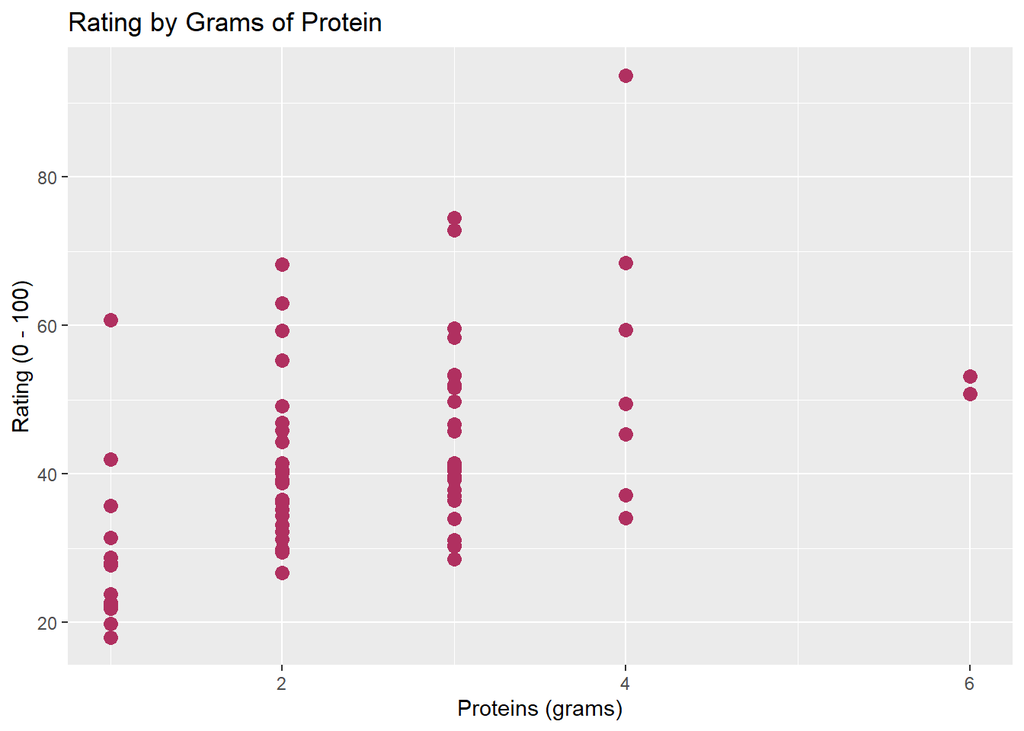

There seems to be a positive relationship between the cereal ratings and grams of protein present in the cereal.

Based on a linear regression, the relationship is statistically significant at the alpha = .01 level.

R-squared is .2121, indicating that the linear model’s relationship between the two accounts for about 21% of the variation in the data.

```r
  summary(lm(data = Cereal, rating~protein))
```

```
##
## Call:
## lm(formula = rating ~ protein, data = Cereal)
##
## Residuals:
##     Min      1Q  Median      3Q     Max
## -17.127  -8.594  -3.799   6.633  42.438
##
## Coefficients:
##             Estimate Std. Error t value Pr(>|t|)
## (Intercept)   27.027      3.718   7.269 3.51e-10 ***
## protein        6.060      1.376   4.403 3.64e-05 ***
## ---
## Signif. codes:  0 '***' 0.001 '**' 0.01 '*' 0.05 '.' 0.1 ' ' 1
##
## Residual standard error: 12.5 on 72 degrees of freedom
## Multiple R-squared:  0.2121, Adjusted R-squared:  0.2012
## F-statistic: 19.39 on 1 and 72 DF,  p-value: 3.64e-05
```

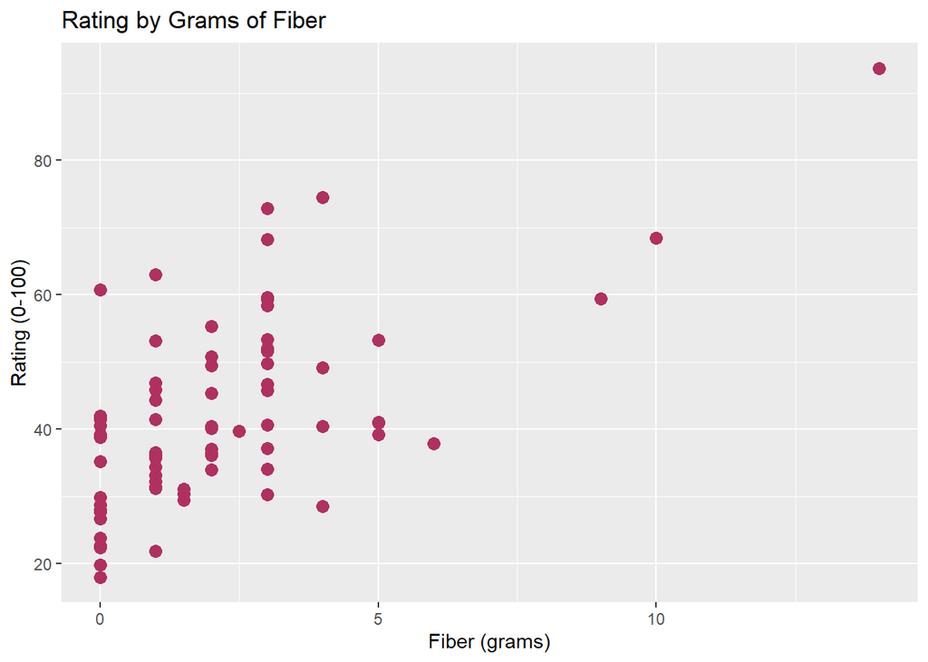

There is a positive relationship between the cereal ratings and grams of fiber present in the cereal.

Based on a linear regression, the relationship is statistically significant at the alpha = .01 level.

R-squared is .3879, indicating that the linear model’s relationship between the two accounts for about 39% of the variation in the data.

```r
  summary(lm(data = Cereal, rating~fiber))
```

```
##
## Call:
## lm(formula = rating ~ fiber, data = Cereal)
##
## Residuals:
##     Min      1Q  Median      3Q     Max
## -20.037  -7.453  -1.747   6.935  27.781
##
## Coefficients:
##             Estimate Std. Error t value Pr(>|t|)
## (Intercept)  34.1955     1.7345  19.715  < 2e-16 ***
## fiber         3.6085     0.5342   6.755 3.12e-09 ***
## ---
## Signif. codes:  0 '***' 0.001 '**' 0.01 '*' 0.05 '.' 0.1 ' ' 1
##
## Residual standard error: 11.02 on 72 degrees of freedom
## Multiple R-squared:  0.3879, Adjusted R-squared:  0.3794
## F-statistic: 45.62 on 1 and 72 DF,  p-value: 3.124e-09
```

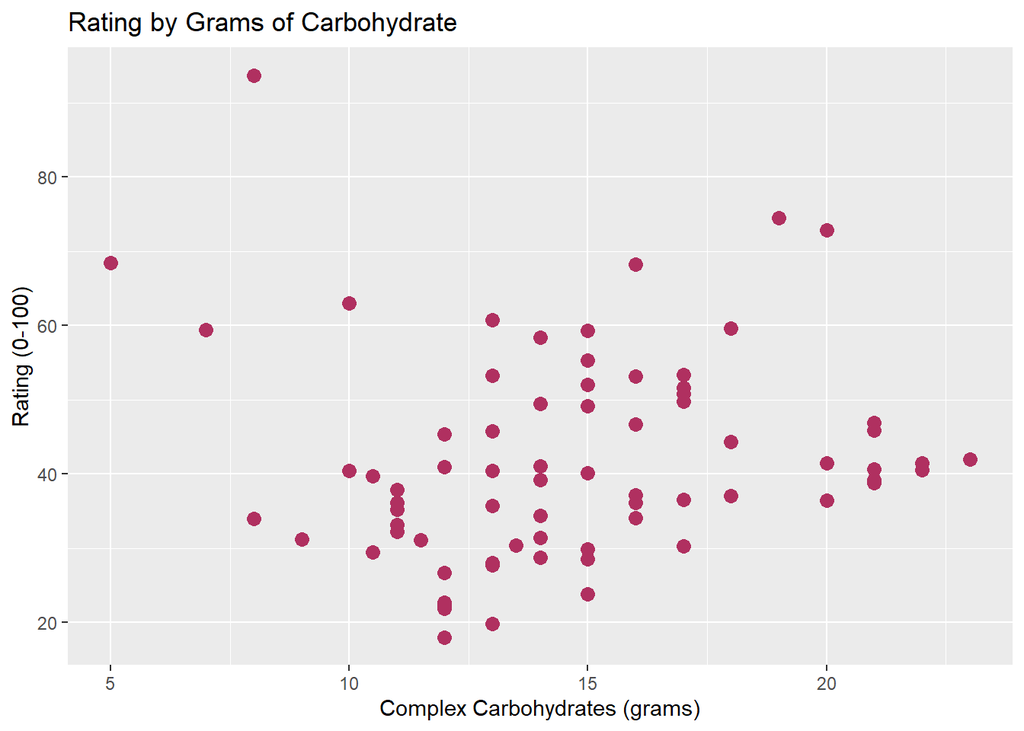

On a glance at the scatterplate, grams of complex carbohydrates and rating do not seem to correlate.

A linear model of the relationship between the two variables shows a p-value greater than an alpha of .05, indicating a lack of significant relationship between the two.

```r
  summary(lm(data = Cereal, rating~carbo))
```

```
##
## Call:
## lm(formula = rating ~ carbo, data = Cereal)
##
## Residuals:
##     Min      1Q  Median      3Q     Max
## -23.532  -8.934  -2.658   7.476  52.899
##
## Coefficients:
##             Estimate Std. Error t value Pr(>|t|)
## (Intercept)  39.2670     6.4326   6.104 4.72e-08 ***
## carbo         0.1924     0.4231   0.455    0.651
## ---
## Signif. codes:  0 '***' 0.001 '**' 0.01 '*' 0.05 '.' 0.1 ' ' 1
##
## Residual standard error: 14.06 on 72 degrees of freedom
## Multiple R-squared:  0.002862,   Adjusted R-squared:  -0.01099
## F-statistic: 0.2067 on 1 and 72 DF,  p-value: 0.6508
```

## Top 10 Rated Cereals

```r
highest_rating_cereals
```

```
##                         name calories protein fat fiber carbo sugars   rating
## 1  All-Bran with Extra Fiber       50       4   0    14     8      0 93.70491
## 2     Shredded Wheat 'n'Bran       90       3   0     4    19      0 74.47295
## 3  Shredded Wheat spoon size       90       3   0     3    20      0 72.80179
## 4                  100% Bran       70       4   1    10     5      6 68.40297
## 5             Shredded Wheat       80       2   0     3    16      0 68.23588
## 6               Puffed Wheat       50       2   0     1    10      0 63.00565
## 7                Puffed Rice       50       1   0     0    13      0 60.75611
## 8          Nutri-grain Wheat       90       3   0     3    18      2 59.64284
## 9                   All-Bran       70       4   1     9     7      5 59.42551
## 10   Strawberry Fruit Wheats       90       2   0     3    15      5 59.36399
```

## Bottom 10 Rated Cereals

```r
lowest_rating_cereals %>% arrange(desc(rating))
```

[output not shown]

## 10 Highest Calorie Cereals

```r
highest_calories_cereals
```

```
##                                 name calories protein fat fiber carbo sugars
## 1               Mueslix Crispy Blend      160       3   2   3.0  17.0     13
## 2   Muesli Raisins; Dates; & Almonds      150       4   3   3.0  16.0     11
## 3  Muesli Raisins; Peaches; & Pecans      150       4   3   3.0  16.0     11
## 4             Just Right Fruit & Nut      140       3   1   2.0  20.0      9
## 5          Nutri-Grain Almond-Raisin      140       3   2   3.0  21.0      7
## 6                  Total Raisin Bran      140       3   1   4.0  15.0     14
## 7                            Basic 4      130       3   2   2.0  18.0      8
## 8               Oatmeal Raisin Crisp      130       3   2   1.5  13.5     10
## 9                  100% Natural Bran      120       3   5   2.0   8.0      8
## 10                      Cap'n'Crunch      120       1   2   0.0  12.0     12
##      rating
## 1  30.31335
## 2  37.13686
## 3  34.13976
## 4  36.47151
## 5  40.69232
## 6  28.59278
## 7  37.03856
## 8  30.45084
## 9  33.98368
## 10 18.04285
```

## 10 Lowest Calorie Cereals

```r
lowest_calories_cereals %>% arrange(desc(calories))
```

[output not shown]

[Back to Homepage](https://caseyot6.github.io/)